# mQTL p-values by type of association

I was a bit concerned that the distribution of pvalues looked bad - very many p-values of 0. I just wanted to see what what the random effects p-values looked like by comparison.

```r
library(knitr)
library(dplyr)
```

```r
library(ggplot2)
library(tidyr)

load("../../results/16/16_clumped.rdata")
```

How many p-values are 0 for different models?

```r
group_by(clumped, cis == "TRUE") %>%
    summarise(
        count=n(),
        prop_fixed_0=sum(pval == 0) / n(),
        prop_ARE_0=sum(PvalueARE == 0) / n(),
        prop_MRE_0=sum(PvalueMRE == 0) / n()
    ) %>%
    kable
```

| cis == “TRUE” | count | prop_fixed_0 | prop_ARE_0 | prop_MRE_0 |
| --- | --- | --- | --- | --- |
| FALSE | 24443 | 0.3337152 | 0.0011455 | 0.0004500 |
| TRUE | 260376 | 0.4378015 | 0.0037984 | 0.0010754 |

Lots of pvalues of 0 for fixed effects model. They seem to be typically those with a large number of effects in the same direction

```r
table(subset(clumped, pval == 0)$Direction) %>% sort(decr=TRUE) %>% as.data.frame %>% head(30) %>% kable
```

| Var1 | Freq |
| --- | --- |
| ++++++++++++++++++++++++?+++++++++++ | 1422 |
| ————————?———– | 1382 |
| ++++++++++++++++++++++++++++++++++++ | 947 |
| ———————————— | 938 |
| +++++++?++++++++++++++++?+++++++++++ | 579 |
| ——-?—————-?———– | 511 |
| ————————?-??——– | 369 |
| ++++++++++++++++++++++++?+??++++++++ | 350 |
| ——-?-?————–?———– | 345 |
| +++++++?+?++++++++++++++?+++++++++++ | 330 |
| ————————?-?——— | 257 |
| +++++++?+?++++++++++++++?+??++++++++ | 236 |
| ——-?-?————–?-??——– | 233 |
| ++++++++++++++++++++++++?+?+++++++++ | 206 |
| ++++++?+++++++++++++++++?+++++++++++ | 188 |
| +++++++?++++++++++++++++?+??++++++++ | 185 |
| ——-?—————-?-??——– | 184 |
| ——?—————–?———– | 184 |
| +++++++++++++++++++++?++?+++++++++++ | 181 |
| ?++??++???++?++?++++??++?+?+?++??+++ | 178 |
| ———————?–?———– | 168 |
| ————————–??——– | 166 |
| ++++++++++++++++++++++++++??++++++++ | 166 |
| ?–??–???–?–?—-??–?-?-?–??— | 158 |
| +++++++?+?++++++++++++++?+?+++++++++ | 153 |
| ——-?-?————–?——?—- | 142 |
| ——-?-?————–?-?——— | 141 |
| +++++++?+?++++++++++++++?++++++?++++ | 140 |
| ———————?————– | 134 |
| ——-?—————-?-?——— | 129 |

What is the distribution of p-values for different meta analysis models? Fix 0 to the smallest non-0 p-value:

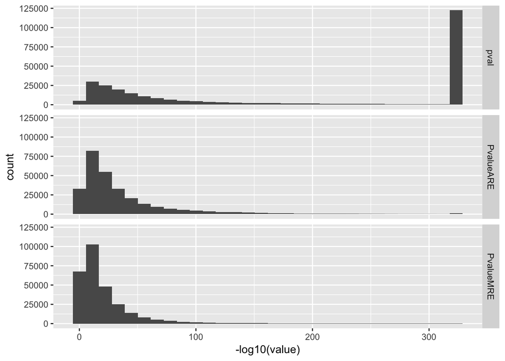

```r
minval <- subset(clumped, pval != 0)$pval %>% min
clumped$pval[clumped$pval == 0] <- minval
clumped$PvalueARE[clumped$PvalueARE == 0] <- minval
clumped$PvalueMRE[clumped$PvalueMRE == 0] <- minval

temp <- gather(subset(clumped, select=c(pval, PvalueMRE, PvalueARE)))
ggplot(temp, aes(x=-log10(value))) +
geom_histogram() +
facet_grid(key ~ .)
```

What is the distribution for cis-only, trans-only and ambivalent CpGs and SNPs? Use threshold of `cis = 1e-10` and `trans = 1e-14` to calculate this (it will vary for different thresholds)

```r
sig <- subset(clumped, (pval < 1e-10 & cis) | (pval < 1e-14 & !cis) )
snptype <- group_by(sig, snp) %>%
    summarise(snpt=sum(unique(as.numeric(cis) + 1)))
snptype$snpt <- dplyr::recode(as.character(snptype$snpt), "1"="Trans only", "2"="Cis only", "3"="Ambivalent")

cpgtype <- group_by(sig, cpg) %>%
    summarise(cpgt=sum(unique(as.numeric(cis) + 1)))
cpgtype$cpgt <- dplyr::recode(as.character(cpgtype$cpgt), "1"="Trans only", "2"="Cis only", "3"="Ambivalent")

sig <- merge(sig, snptype, by="snp")
sig <- merge(sig, cpgtype, by="cpg")
```

Count the cis/trans/ambivalent SNPs and CpGs

```r
table(cpgtype$cpgt)
```

```
##
## Ambivalent   Cis only Trans only
##      11807     168197       7309
```

```r
table(snptype$snpt)
```

```
##
## Ambivalent   Cis only Trans only
##       2605     204625      13083
```

**The ambivalent SNPs are the most uncommon - is this correct? When we were discussing I think it was the trans only that were problematic?**

What proportion of associations are significant for ARE and MRE, grouped by type?

```r
sig$sigARE <- (sig$PvalueARE < 1e-10 & sig$cis) | (sig$PvalueARE < 1e-14 & !sig$cis)
sig$sigMRE <- (sig$PvalueMRE < 1e-10 & sig$cis) | (sig$PvalueMRE < 1e-14 & !sig$cis)

group_by(sig, snpt, cpgt) %>%
summarise(psigARE = sum(sigARE)/n(), psigMRE=sum(sigMRE)/n(), count=n()) %>%
kable
```

| snpt | cpgt | psigARE | psigMRE | count |
| --- | --- | --- | --- | --- |
| Ambivalent | Ambivalent | 0.8470643 | 0.6899513 | 4309 |
| Ambivalent | Cis only | 0.8562722 | 0.6424581 | 3938 |
| Ambivalent | Trans only | 0.8400208 | 0.4715998 | 1919 |
| Cis only | Ambivalent | 0.8636491 | 0.7343267 | 17785 |
| Cis only | Cis only | 0.7977231 | 0.6115122 | 221088 |
| Trans only | Ambivalent | 0.7528058 | 0.5838945 | 10692 |
| Trans only | Trans only | 0.7897894 | 0.4343183 | 6836 |

```r
group_by(sig, snpt) %>%
summarise(psigARE = sum(sigARE)/n(), psigMRE=sum(sigMRE)/n(), count=n()) %>%
kable
```

| snpt | psigARE | psigMRE | count |
| --- | --- | --- | --- |
| Ambivalent | 0.8493016 | 0.6303364 | 10166 |
| Cis only | 0.8026315 | 0.6206562 | 238873 |
| Trans only | 0.7672296 | 0.5255591 | 17528 |

```r
group_by(sig, cpgt, cpgt) %>%
summarise(psigARE = sum(sigARE)/n(), psigMRE=sum(sigMRE)/n(), count=n()) %>%
kable
```

| cpgt | psigARE | psigMRE | count |
| --- | --- | --- | --- |
| Ambivalent | 0.8253218 | 0.6794363 | 32786 |
| Cis only | 0.7987477 | 0.6120537 | 225026 |
| Trans only | 0.8007995 | 0.4424900 | 8755 |

Distribution of pvalues:

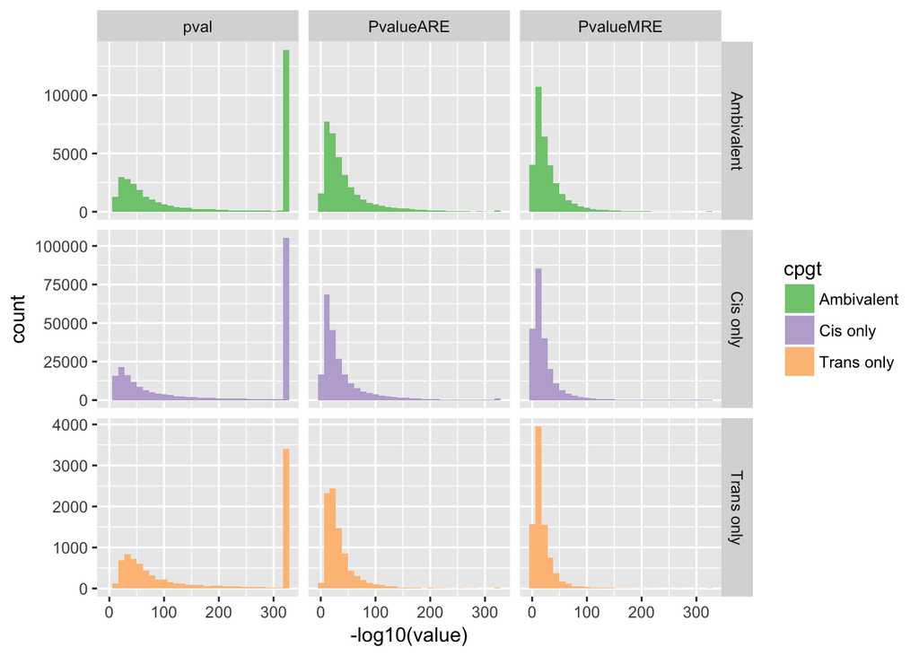

```r
gather(subset(sig, select=c(cpgt, pval, PvalueMRE, PvalueARE)), key="key", value="value", pval, PvalueMRE, PvalueARE) %>%
ggplot(aes(x=-log10(value))) +
geom_histogram(aes(fill=cpgt)) +
facet_grid(cpgt ~ key, scale="free_y") +
scale_fill_brewer(type="qual")
```

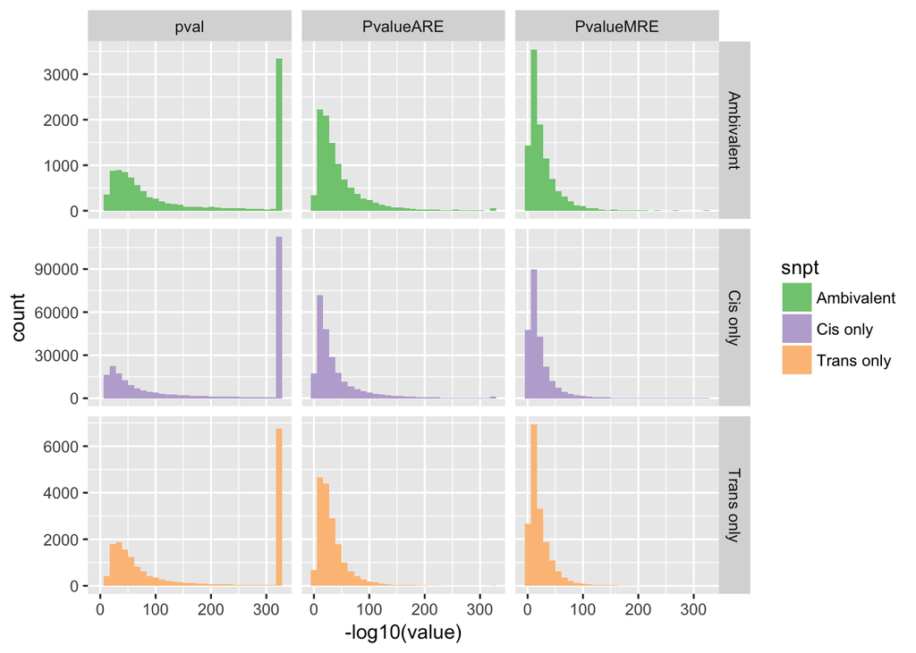

```r
gather(subset(sig, select=c(snpt, pval, PvalueMRE, PvalueARE)), key="key", value="value", pval, PvalueMRE, PvalueARE) %>%
ggplot(aes(x=-log10(value))) +
geom_histogram(aes(fill=snpt)) +
facet_grid(snpt ~ key, scale="free_y") +
scale_fill_brewer(type="qual")
```